# Analysis of the FRN behavioral pilot data_new

**請直接翻到最下面看Additional analysis**

### N of subjects

LC: N = 13  
BDM: N = 17  
QSR: N = 10

```python
import os
import glob
import numpy as np
import pandas as pd
import seaborn as sns
from matplotlib import*
import matplotlib.pyplot as plt
%config IPCompleter.greedy=True
%matplotlib inline
```

### Functions

**Note:** For LC, the switching point is defined as below: If player starts to switch at row $N, (N=1,2,...,10,11)$, the switching point (i.e., the elicited belief) is $(N-1)\times 10$.

```python
#Functions
def readfile(form, date):

    path=os.getcwd()+'/raw_data/'

    fname = f'{path}risk_{form}_main_game_2023-{date[0]}-{date[1]}.csv'
    #print(fname)
    try:
        raw = pd.read_csv(fname)
    except (FileNotFoundError): #if not exist:
        print(f'Raw data {fname} does not exist!')
    return(raw)

def prob(lst): ##list for input
    pp=int() #posterior prob.
    l = len(lst)
#    if is_red == 0: #red_jar
    if (lst == [0,2,2]) | (lst == [0,0,1]): # 1B, 2B1R
        pp = 33
    elif (lst == [1,2,2]) | (lst == [0,1,1]): # 1R, 1B2R
        pp = 67
    elif (lst == [2,2,2]) | (lst == [0,1,2]): # 3NA, 1B1R
        pp = 50
    elif lst == [0,0,2]: #2B
        pp = 20
    elif lst == [1,1,2]: #2R
        pp = 80
    elif lst == [0,0,0]: #3B
        pp = 11
    elif lst == [1,1,1]: #3R
        pp = 89
    return(pp)

def preprocess(df, form, date, LC = False):
    tp=df.dropna(how= 'all', axis=1).dropna(axis=0) #first drop empty column then drop rows w/ empty values
    out = []
    for i in tp.index:
        ball = list(tp.loc[i,'player.outcome1':'player.outcome3'])
        ball.sort()
        out.append(ball)
    tp['outcome'] = out
    tp['PostProb'] = list(map(prob, tp['outcome'])) #posterior prob
    #tp = tp.assign(date = str(str(date[0]) + str(date[1])),
    #               form_type = form)
    tp['date'] =  f'{date[0]}-{date[1]}'
    tp['form_type'] = form
    if LC:
        tp['sw'] = list(map(lambda x: (x-1)*10 \
                                  if x <11 else 100,
                                  tp.loc[:,'player.switching_point']))

        tp['sw_upper_bound'] = list(map(lambda x: x*10-5 \
                                      if x <11 else 100,
                                      tp.loc[:,'player.switching_point'])) #index of rows to numbers
        tp=tp.drop(['player.switching_point', 'outcome'],axis=1).rename(columns={'sw':'player.switching_point'}) #rename to the same format
    else: tp=tp.drop(['outcome'],axis=1)

    return(tp)

#class to cleaning df and plotting
class data:
    def __init__(self, form, date):
        #self.inp = df
        self.form = form
        self.date = date


    def prepro(self):
        path = os.getcwd()+'/pipeline'
        date = self.date
        form = self.form
        fname = f'2023{date[0]}{date[1]}_{form}.csv'
        try: #read_existed_file
            df = pd.read_csv(f'{path}/{fname}')
            print(f'Exist preprocessed data {fname} readed.')

        except(FileNotFoundError): #if not exist, create it from original data
            if self.form == 'LC':
                is_LC = True
            else:
                is_LC = False

            raw = readfile(form, date)
            df = preprocess(raw, form, date, LC = is_LC)

            try: #store it in new directory
                os.mkdir(path)
            except FileExistsError: #if the directory is exist
                pass

            df.to_csv(f'{path}/{fname}', index=False)
            print(f'Preprocessed data {fname} is created in pipeline/ folder.')
        return(df)


    def agg_plot(self, pilot=False):
        df = self.prepro()
        count = df.groupby(by=['PostProb','player.switching_point']).count()['participant.id_in_session'].to_numpy()

        s=df[['PostProb','player.switching_point']].to_numpy()

        value= np.unique(s,axis = 0 )#return unique rows
        cnt=pd.DataFrame(value,columns=['PostProb','switching_point'] )
        cnt['count'] = count

        fig,ax = plt.subplots(figsize =(10, 10))

        ax.scatter(x = cnt['PostProb'], y = cnt['switching_point'],s=cnt['count']*6,
                   facecolor ='none',edgecolor = 'orange',linewidth=2)
        ax.plot([0,100],[0,100],'r--') #diagonal
        ax.set(xticks = [11,20,33,50,66,80,89],
               xlabel ='Post_Prob(%)',
               ylabel ='Subj_Prob(%)')

        if pilot: p="pilot"
        else: p=""

        fig.suptitle(f'{p}2023{self.date[0]}{self.date[1]}_{self.form}_pooled', fontsize=16)
        fig.tight_layout()
        fig.savefig(f'{p}2023{self.date[0]}{self.date[1]}_{self.form}_pooled.png',
                    format ='png', facecolor='white')
        #return(fig)

    def indiv_plot(self, n_row=4, height = 16, width_per_col=4):
        df = self.prepro()
        a = df['participant.id_in_session'].to_numpy()
        N = len(np.unique(a))
        num_col = lambda x: x//n_row+1 if x%n_row > 0 else x//n_row
        n_col = num_col(N)

        fig, axs = plt.subplots(n_row, n_col ,figsize=(n_col*width_per_col, height),layout="constrained")
        for i, j in enumerate(np.unique(a)):
            part = df.loc[df["participant.id_in_session"]==j]
            count = part.groupby(by=['PostProb','player.switching_point']).count()['participant.id_in_session'].to_numpy()

            s=part[['PostProb','player.switching_point']].to_numpy()
            value= np.unique(s,axis = 0 )#return unique rows
            cnt=pd.DataFrame(value,columns=['PostProb','switching_point'] )
            cnt['count'] = count

            cf=axs[i//n_col, i%n_col] #current_figure
            cf.scatter(x = cnt['PostProb'], y = cnt['switching_point'],s=cnt['count']*6,
                   facecolor ='none',edgecolor = 'darkcyan',linewidth=2)
            cf.plot([0,100],[0,100],'r--')

            cf.set(xticks = [11,20,33,50,66,80,89],
               xlabel ='Post_Prob(%)',
               ylabel ='Subj_Prob(%)')
            cf.set_title(f'Sub_{j}')

        fig.suptitle(f'2023{self.date[0]}{self.date[1]}_{self.form}_indiv', fontsize=16)
        fig.savefig(f'2023{self.date[0]}{self.date[1]}_{self.form}_indiv.png',
                    format ='png', facecolor='white')
        #print()
        #return(fig)
```

## The individual and Pool data Comparing the Post_Prob

X axis: the true (posterior) probability of red jar given the drawn balls.  
Y axis: the elicited belief (probability) about the event.

```
Preprocessed data 20230728_LC.csv is created in pipeline/ folder.
Preprocessed data 20230804_BDM.csv is created in pipeline/ folder.
Preprocessed data 20230811_QSR.csv is created in pipeline/ folder.
Exist preprocessed data 20230728_LC.csv readed.
Exist preprocessed data 20230728_LC.csv readed.
Exist preprocessed data 20230804_BDM.csv readed.
Exist preprocessed data 20230804_BDM.csv readed.
Exist preprocessed data 20230811_QSR.csv readed.
Exist preprocessed data 20230811_QSR.csv readed.
```

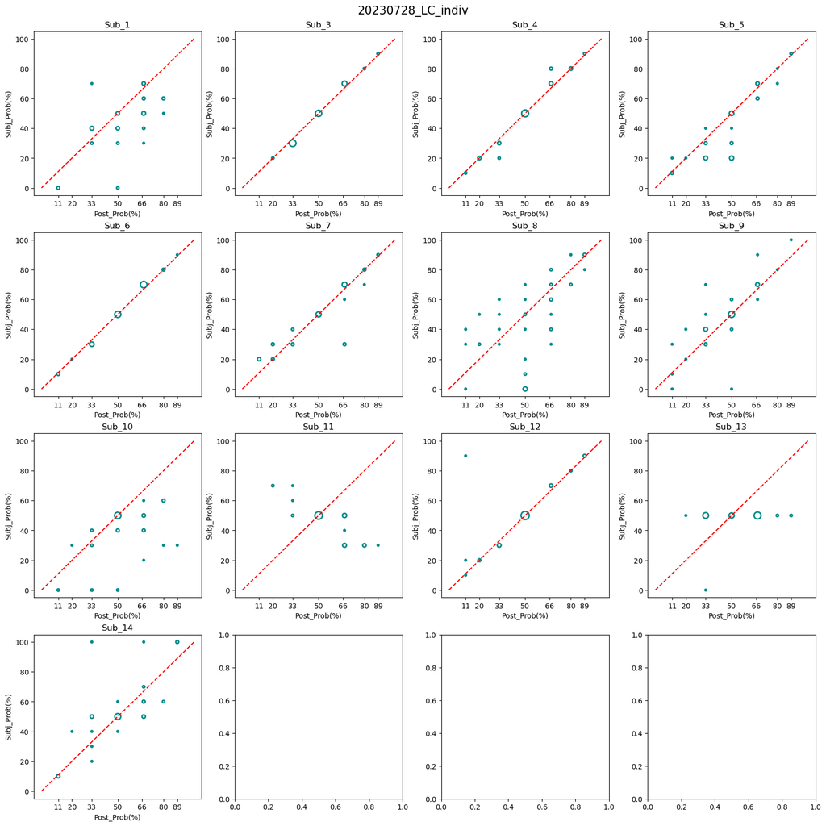

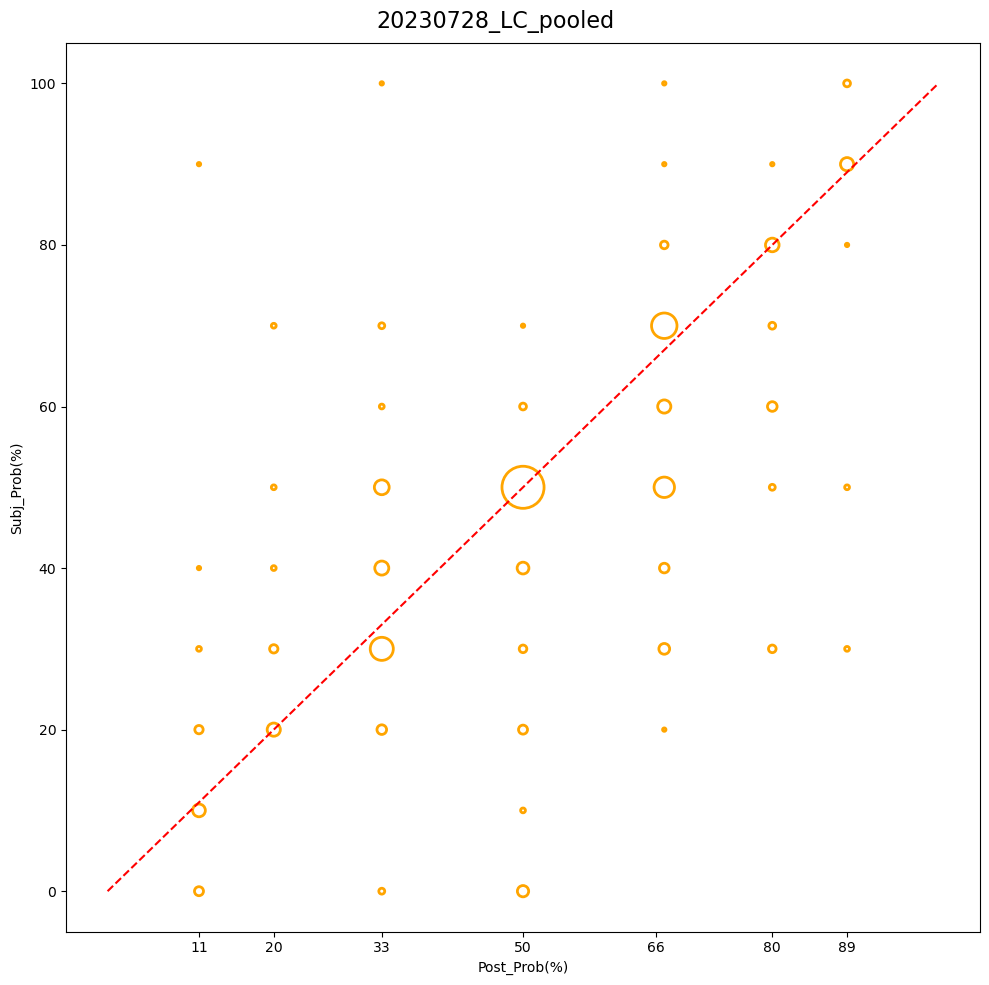

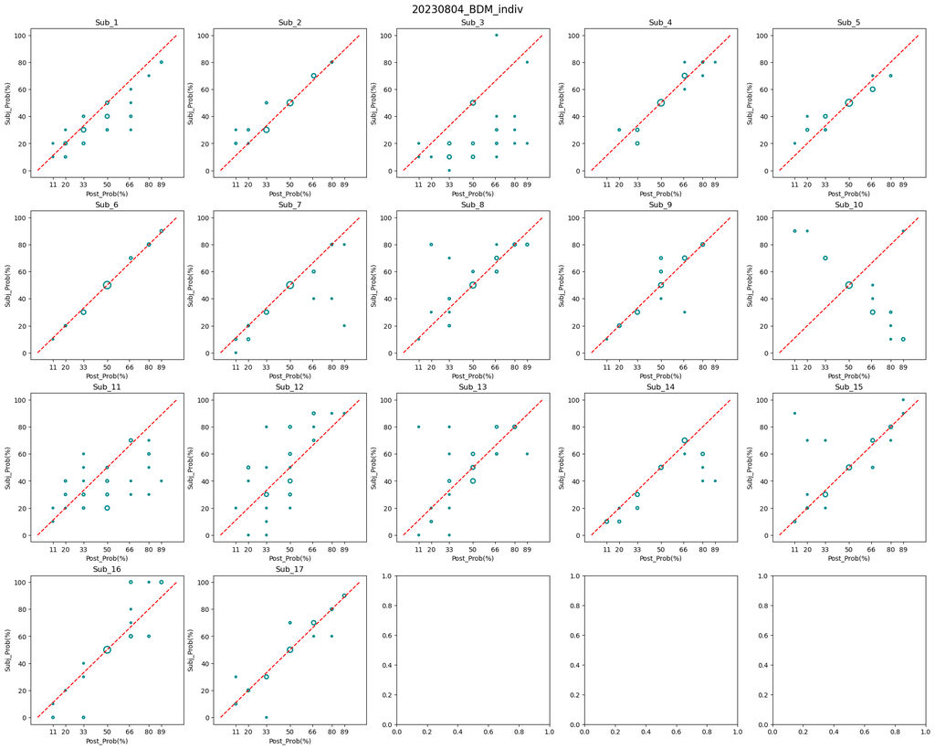

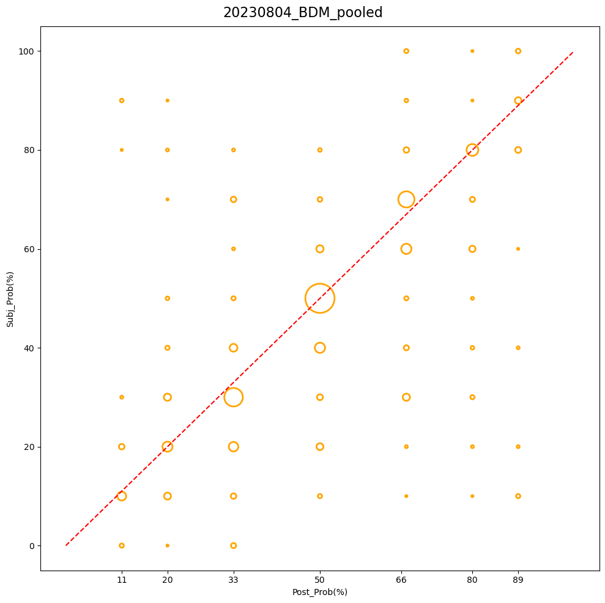

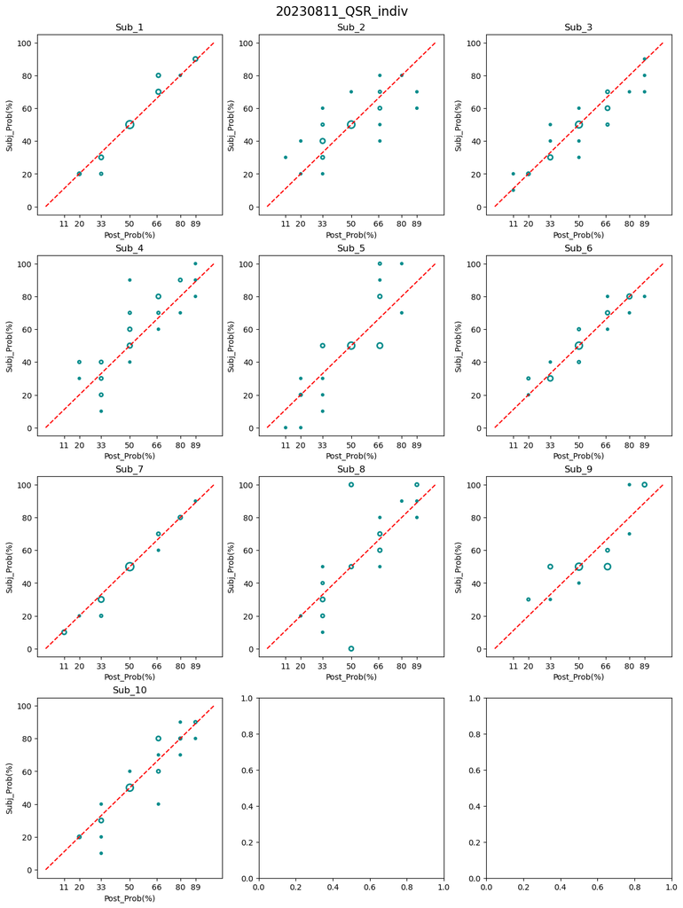

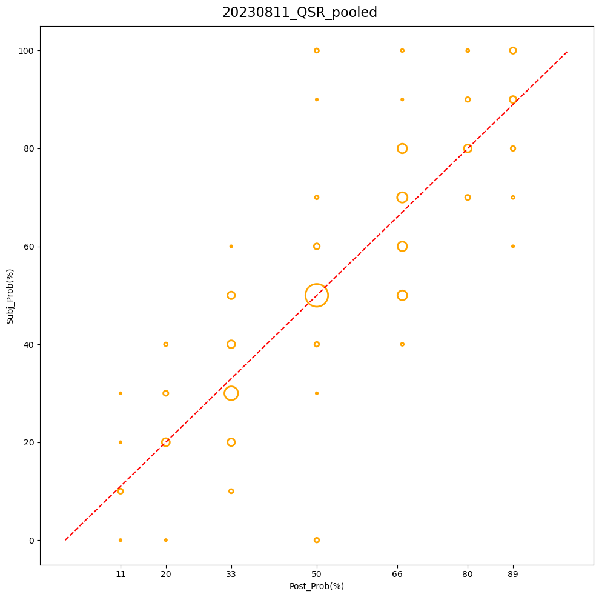

```python
#an easy tryout
ad=data("LC",["07","28"])
LC=ad.prepro()

ad2=data("BDM",["08","04"])
BDM=ad2.prepro()

ad3=data("QSR",["08","11"])
QSR=ad3.prepro()
for i in [ad, ad2, ad3]:
    i.indiv_plot()
    i.agg_plot()
#ad.indiv_plot()
```

LC的sub_11, BDM的sub_10都很明顯填答相反方向，但QSR沒這情況。 大致上走向差不多，只是QSR的左上右下比較乾淨沒有看到受試者填答而已(但可能是樣本數問題)。

```python
##another function that merges exist data
def merge_files_in(path = os.getcwd()+'/pipeline'):
    allcsv = glob.glob(f'{path}/[0-9]*.csv')
    for i,j in enumerate(allcsv):
        if i==0:
            final_df = pd.read_csv(j)
            print(f'File {j} readed.')
        else:
            tp_df = pd.read_csv(j)
            final_df = pd.merge(final_df, tp_df, how = "outer")
            print(f'File {j} readed and merged.')
            #print(final_df.shape)
    final_df.to_csv(f'{path}/merged.csv', index = False)
    print('Merged data created')
    return(final_df)

#total participants
def print_N(df, to_print = False):
    tp1=df.groupby(['form_type','participant.code'])[['player.switching_point']].count()
    tp2=tp1.groupby(level = 'form_type').count()
    return(tp2)
    if to_print:
        for i, j  in enumerate(tp2.index):
            print(f' {j} : {tp2.iloc[i,0]} participants in total.')
    else: pass
```

### The Median, 10th quantile and 90th quantile of the 3 forms (pool all responses across participants)

```python
h = merge_files_in()
print_N(h, True)
quan_ser = h.groupby(['PostProb','form_type'])['player.switching_point'].quantile([.5,.1,.9]).astype(int)
#quan_ser.shape
quan_arr =quan_ser.to_numpy().reshape(7,9)

coln= ['BDM_Median','BDM_10thQ','BDM_90thQ',
       'LC_Median','LC_10thQ','LC_90thQ',
       'QSR_Median','QSR_10thQ','QSR_90thQ']
dff=pd.DataFrame(quan_arr, columns= coln, index= [11,20,33,50,67,80,89])
path =f'{os.getcwd()}/pipeline'
dff.to_csv(f'{path}/median_Quantile.csv', index_label='PostProb')
print('The Median, 10th quantile and 90th quantile of the 3 forms')
dff
```

```
File /home/wcnoname5/EEG_risk/pilot_2023_Jul/pipeline/20230811_QSR.csv readed.
File /home/wcnoname5/EEG_risk/pilot_2023_Jul/pipeline/20230728_LC.csv readed and merged.
File /home/wcnoname5/EEG_risk/pilot_2023_Jul/pipeline/20230804_BDM.csv readed and merged.
Merged data created
The Median, 10th quantile and 90th quantile of the 3 forms
```

|  | BDM_Median | BDM_10thQ | BDM_90thQ | LC_Median | LC_10thQ | LC_90thQ | QSR_Median | QSR_10thQ | QSR_90thQ |
| --- | --- | --- | --- | --- | --- | --- | --- | --- | --- |
| 11 | 10 | 4 | 60 | 10 | 0 | 30 | 10 | 8 | 22 |
| 20 | 20 | 10 | 50 | 20 | 20 | 50 | 20 | 20 | 36 |
| 33 | 30 | 20 | 49 | 30 | 20 | 50 | 30 | 20 | 50 |
| 50 | 50 | 40 | 50 | 50 | 24 | 50 | 50 | 50 | 60 |
| 67 | 70 | 30 | 80 | 60 | 40 | 70 | 70 | 50 | 80 |
| 80 | 80 | 30 | 80 | 70 | 30 | 80 | 80 | 70 | 90 |
| 89 | 80 | 11 | 100 | 90 | 50 | 100 | 90 | 77 | 100 |

三者Median其實都和實際機率對應的很靠近，沒什麼大差異。Holt and Smith Table 2指出QSR toward to extreme的情況也無發生。

## Average Absolute Deviation from Bayes’ Predictions

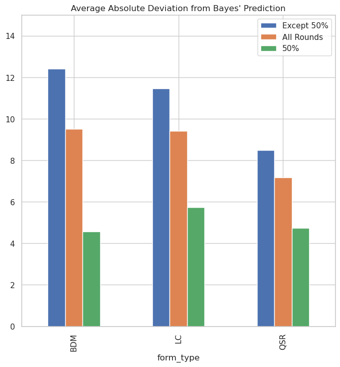

```python
#AAD_plotting
##Re-consider: should average over all participants first and plot the distribution?
df_all=h.assign(Abs_dev = abs(h['player.switching_point']-h['PostProb']),
             dev = h['player.switching_point']-h['PostProb'])


df_not50=df_all.loc[df_all['PostProb']!=50]
df_50=df_all.loc[df_all['PostProb']==50]




d = {'not_50%':   df_not50.groupby(['form_type'])['Abs_dev'].mean(),
     'All': df_all.groupby(['form_type'])['Abs_dev'].mean(),
     'is_50%':   df_50.groupby(['form_type'])['Abs_dev'].mean()
    }

sns.set(style="whitegrid")
fig, ax = plt.subplots(figsize=(8, 8))
pd.DataFrame(data = d).plot.bar(ylim =(0,15), ax=ax)
#plt.grid(True, axis = 'y' ,alpha = .7)
ax.legend(['Except 50%','All Rounds', '50%'])
plt.title('Average Absolute Deviation from Bayes\' Prediction')
fig.savefig('average_absolute_deviation_from_prediction.png',
                    format ='png', facecolor='white')
##Violin Plot (or simply scatter) can be added too.
```

```python
#One-Way ANOVA to check if QSR has lower absolute deviations for each participants compare to other treatment.
from scipy import stats

absdev=df_all.groupby(['participant.code','form_type'
                        ])['Abs_dev',].mean()

stats.f_oneway(absdev.iloc[absdev.index.get_level_values('form_type') == 'QSR'],
              absdev.iloc[absdev.index.get_level_values('form_type') == 'LC'],
              absdev.iloc[absdev.index.get_level_values('form_type') == 'BDM'])
```

```
F_onewayResult(statistic=array([0.44197775]), pvalue=array([0.64611305]))
```

"**Result 1**: *The Lottery Choice method yields lower average absolute deviations from Bayes’ Rule predictions than all other mechanisms explored in this paper. However, this difference is only significant when Lottery Choice is compared to the Quadratic Scoring Rule method with neutral terminology where probability labels are not used (QSR-numbers)." (Holt and Smith, 2016)* (對應其Figure 3)

這次Pilot做起來 QSR 的deviation 反而是最低的，但沒有顯著低於其他兩者。

## Directions of Deviations in Reported Probabilities from Bayes’ Predictions when the Bayes’ Rule Prediction $\neq \frac{1}{2}$

The table shows the **Median** percentage (across individual subject percentages) of correct decisions, deviations toward the center, deviations toward the boundary, and decisions on the wrong side of one-half.

**just_make** : The reproted probability is $\pm 5\%$ from the true probability.  
**more_extreme** : The reproted probability deviates toward extreme (100% or 0%, depends on the true probability).  
**more_central** : The reproted probability deviates toward central (50%).  
**wrong_direction** : The reproted probability is on the oposite side of one-half from the true probability.  
**N**: Number of participants.

*Note: in the original paper, mean is calculated but with small sample, both median and mean are presneted.*

```python
def direction(pp, sw, bound=5):# = df.iloc[i][['PostProb','dev','player.switching_point']]
    dv = sw-pp
    if abs(dv) < bound:
        m=1 #make
        e=0
    else:
        m=0
        if (np.sign(pp-50)*np.sign(sw-50) != 1):
            e=0
        elif (np.sign(pp-50)*np.sign(sw-50) == 1) & (pp>50):
            e=1
        elif (np.sign(pp-50)*np.sign(sw-50) == 1) & (pp<50):
            e=-1
        #please think about "if pp ==50", though one shouldn't make it happen

    ext = np.sign(dv*e) #extreme compare to postProb & central
    wrong = 1 if (m==0) & (ext == 0) else 0 # wrong direction
    return(m, int(ext==1), int(ext==-1), wrong)

df_not50.loc[:,['just_make','more_extreme',
         'more_central','wrong_direction']] = list(map(direction,
                                                df_not50['PostProb'], df_not50['player.switching_point']))

indivs=df_not50.groupby(['participant.code','form_type'
                        ])[['just_make','more_extreme',
                          'more_central','wrong_direction']].mean().round(2)
Npart = indivs.groupby(['form_type'])['just_make'].count().to_numpy()

print("Median")
path =f'{os.getcwd()}/pipeline'

summ = indivs.groupby(['form_type']).median().round(4).assign(N = Npart)
summ.to_csv(
    f'{path}/response_type_median_by_individual.csv')
summ
```

```
Median
```

| form_type | just_make | more_extreme | more_central | wrong_direction | N |
| --- | --- | --- | --- | --- | --- |
| BDM | 0.43 | 0.12 | 0.170 | 0.120 | 17 |
| LC | 0.46 | 0.10 | 0.240 | 0.090 | 13 |
| QSR | 0.42 | 0.22 | 0.225 | 0.055 | 10 |

```python
print('Mean')
indivs.groupby(['form_type']).mean().round(4).assign(N = Npart)
```

```
Mean
```

| form_type | just_make | more_extreme | more_central | wrong_direction | N |
| --- | --- | --- | --- | --- | --- |
| BDM | 0.4847 | 0.1600 | 0.1982 | 0.1559 | 17 |
| LC | 0.4662 | 0.0869 | 0.1738 | 0.2708 | 13 |
| QSR | 0.4340 | 0.2100 | 0.2180 | 0.1360 | 10 |

```python
#One-Way ANOVA to check if QSR is more likely to deviate torward extreme values.
from scipy import stats

extreme=df_not50.groupby(['participant.code','form_type'
                        ])['more_extreme'].mean()

stats.f_oneway(extreme.iloc[extreme.index.get_level_values('form_type') == 'QSR'],
              extreme.iloc[extreme.index.get_level_values('form_type') == 'LC'],
              extreme.iloc[extreme.index.get_level_values('form_type') == 'BDM'])
```

```
F_onewayResult(statistic=2.039418607819683, pvalue=0.14447618668328402)
```

跟Holt and Smith比，本次看不出來三個form中LC有明顯好過其他兩者，median LC just_make 比例最高，但Mean 卻是BDM最高，而且三者的差異也都在5%內，表現都差不多。 \ 另外，QSR的傾向極端(deviate torward extreme)的確有稍微表現出來。無論是mean或者median，more_extreme的比例都是QSR最高，但沒有統計上顯著高於兩者。

### Additional Plots

只是想看看各種機率下回答差距的分布圖。 和用箱型圖看各種填答的分布。

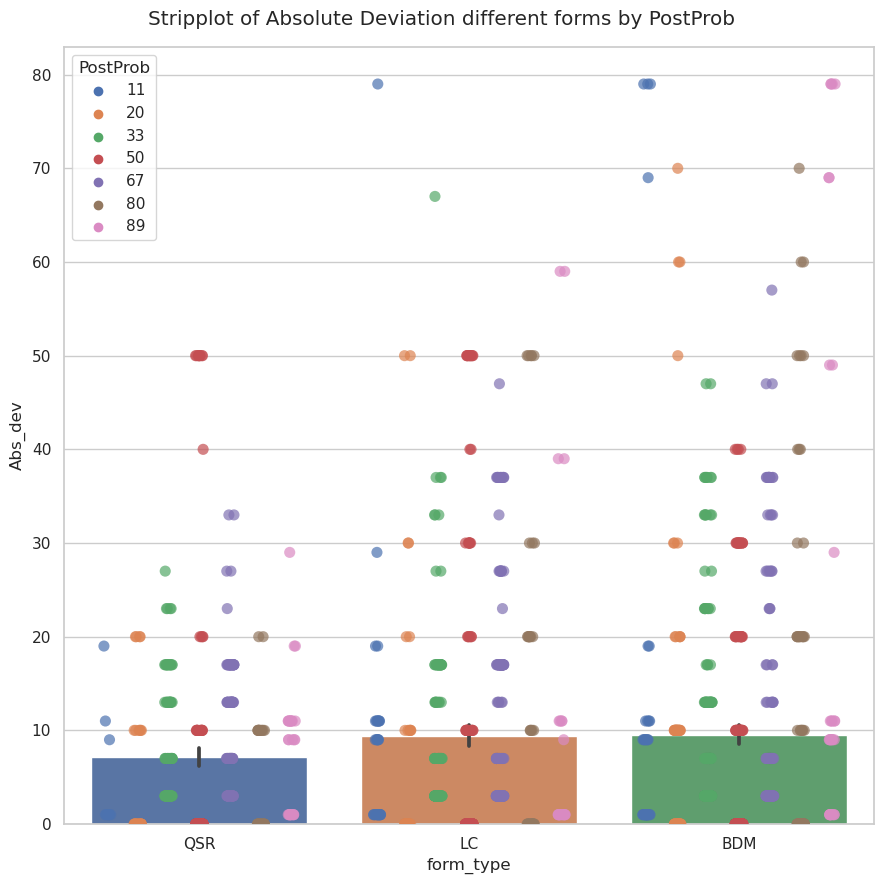

```python
#sns.swarmplot(data=df_all, x="form_type", y="Abs_dev", size=.7)
sns.set(style="whitegrid")
fig, ax= plt.subplots(figsize = (9,9))
sns.barplot(data=df_all, x = 'form_type', y ='Abs_dev')
sns.stripplot(data=df_all, x="form_type", y="Abs_dev", size=8,
              alpha = .7, hue='PostProb', palette="deep", ax=ax,dodge = True)

fig.suptitle('Stripplot of Absolute Deviation different forms by PostProb')
fig.tight_layout()
fig.savefig('stripplot.png',
                   format ='png', facecolor='white')
```

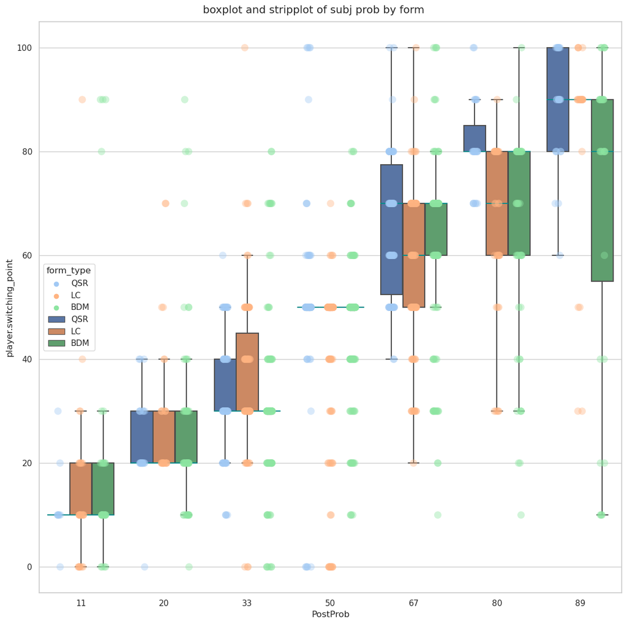

```python
#sns.swarmplot(data=df_all, x="form_type", y="Abs_dev", size=.7)
sns.set(style="whitegrid")
fig, ax= plt.subplots(figsize = (12,12))
#sns.boxplot(data=df_all, x = 'PostProb', y ='player.switching_point',hue='form_type',ax=ax,showfliers = False)

sns.stripplot(data=df_all, x="PostProb", y="player.switching_point", size=10, ax=ax,
             alpha = .4, hue='form_type',palette="pastel", dodge = True)
sns.boxplot(data=df_all, x = 'PostProb', y ='player.switching_point',hue='form_type',ax=ax,
            #flierprops={"marker": "x"},
            showfliers = False,
            medianprops={"color": "darkcyan"})
fig.suptitle('boxplot and stripplot of subj prob by form')
fig.tight_layout()
#fig.savefig('stripplot.png',
#                   format ='png', facecolor='white')
```

### Additional Analysis: Drop some participants

Drop sub_10 in BDM, sub_11, 13 in LC

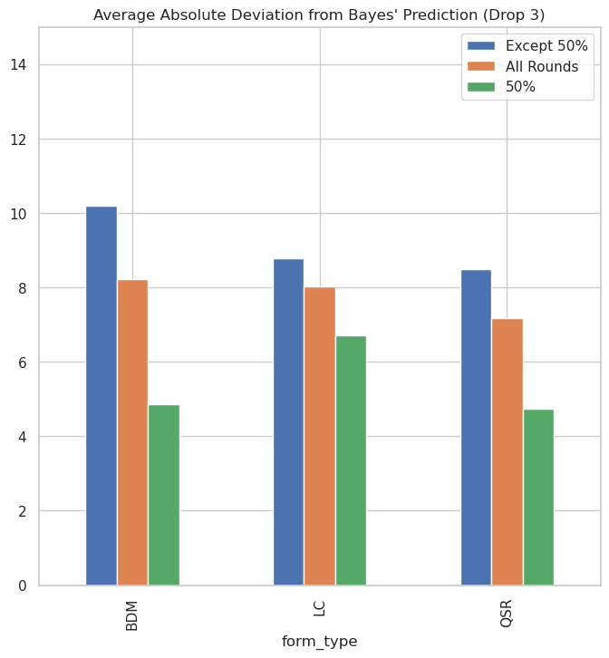

```python
##Drop 3 participants
h=pd.read_csv(f'{os.getcwd()}/pipeline/merged.csv')

a=(h[(h.form_type == 'BDM') & (h['participant.id_in_session']==10)]['participant.code'].unique())
b=(h[(h.form_type == 'LC') & (h['participant.id_in_session'].isin([11,13]))]
            ['participant.code'].unique())
to_drop = np.concatenate((a,b))
drop_3=h.loc[~h['participant.code'].isin(to_drop)]



d3=drop_3.assign(Abs_dev = abs(h['player.switching_point']-h['PostProb']),
             dev = h['player.switching_point']-h['PostProb'])
d3_not50=d3.loc[d3['PostProb']!=50]
d3_50=d3.loc[d3['PostProb']==50]


d = {'not_50%': d3_not50.groupby(['form_type'])['Abs_dev'].mean(),
     'All': d3.groupby(['form_type'])['Abs_dev'].mean(),
     'is_50%': d3_50.groupby(['form_type'])['Abs_dev'].mean()
    }

sns.set(style="whitegrid")
fig, ax = plt.subplots(figsize=(8, 8))
pd.DataFrame(data = d).plot.bar(ylim =(0,15), ax=ax)
#plt.grid(True, axis = 'y' ,alpha = .7)
ax.legend(['Except 50%','All Rounds', '50%'])
plt.title('Average Absolute Deviation from Bayes\' Prediction (Drop 3)')
#fig.savefig('deviation_from_prediction_drop3.png',
#                    format ='png', facecolor='white')
```

- LC, BDM 刪掉一些受試者後，就絕對差異的平均(Average Absolute Deviation)而言，QSR 不管在全部或者是 50% 外仍是最低，表現最好。
  - LC 在 50% 的 condition 就是表現得特別差，BDM 則是在 50% 以外的表現特別差。
- 當然跟原先結果的相比，三個 Form 之間差異變更小了

```python
def direction(pp, sw, bound=5):# = df.iloc[i][['PostProb','dev','player.switching_point']]
    dv = sw-pp
    if abs(dv) < bound:
        m=1 #make
        e=0
    else:
        m=0
        if (np.sign(pp-50)*np.sign(sw-50) != 1):
            e=0
        elif (np.sign(pp-50)*np.sign(sw-50) == 1) & (pp>50):
            e=1
        elif (np.sign(pp-50)*np.sign(sw-50) == 1) & (pp<50):
            e=-1
        #please think about "if pp ==50", though one shouldn't make it happen

    ext = np.sign(dv*e) #extreme compare to postProb & central
    wrong = 1 if (m==0) & (ext == 0) else 0 # wrong direction
    return(m, int(ext==1), int(ext==-1), wrong)

d3_not50.loc[:,['just_make','more_extreme',
         'more_central','wrong_direction']] = list(map(direction,
                                                d3_not50['PostProb'], d3_not50['player.switching_point']))

indivs=d3_not50.groupby(['participant.code','form_type'
                        ])[['just_make','more_extreme',
                          'more_central','wrong_direction']].mean().round(2)
Npart = indivs.groupby(['form_type'])['just_make'].count().to_numpy()

print("Median")
path =f'{os.getcwd()}/pipeline'

summ = indivs.groupby(['form_type']).median().round(4).assign(N = Npart)
#summ.to_csv(
#    f'{path}/response_type_median_by_individual.csv')
summ
```

```
Median
```

| form_type | just_make | more_extreme | more_central | wrong_direction | N |
| --- | --- | --- | --- | --- | --- |
| BDM | 0.485 | 0.145 | 0.175 | 0.105 | 16 |
| LC | 0.560 | 0.120 | 0.250 | 0.080 | 11 |
| QSR | 0.420 | 0.220 | 0.225 | 0.055 | 10 |

```python
print('Mean')
indivs.groupby(['form_type']).mean().round(4).assign(N = Npart)
```

```
Mean
```

| form_type | just_make | more_extreme | more_central | wrong_direction | N |
| --- | --- | --- | --- | --- | --- |
| BDM | 0.5125 | 0.17 | 0.2106 | 0.1056 | 16 |
| LC | 0.5509 | 0.10 | 0.2055 | 0.1409 | 11 |
| QSR | 0.4340 | 0.21 | 0.2180 | 0.1360 | 10 |

```python
#One-Way ANOVA to check if QSR is more likely to deviate torward extreme values.
from scipy import stats

mk=d3_not50.groupby(['participant.code','form_type'
                        ])['just_make'].mean()

stats.f_oneway(mk.iloc[mk.index.get_level_values('form_type') == 'QSR'],
              mk.iloc[mk.index.get_level_values('form_type') == 'LC'],
              mk.iloc[mk.index.get_level_values('form_type') == 'BDM'])
```

```
F_onewayResult(statistic=0.39198682180548844, pvalue=0.6787272767968594)
```

但是如果看填答正確(just_make)的比例，LC不管是中位數或者平均都是三者中最高的，但仍無統計上顯著。

```python
#One-Way ANOVA to check if QSR is more likely to deviate torward extreme values.
from scipy import stats

extreme=d3_not50.groupby(['participant.code','form_type'
                        ])['more_extreme'].mean()

stats.f_oneway(extreme.iloc[extreme.index.get_level_values('form_type') == 'QSR'],
              extreme.iloc[extreme.index.get_level_values('form_type') == 'LC'],
              extreme.iloc[extreme.index.get_level_values('form_type') == 'BDM'])
```

```
F_onewayResult(statistic=1.4567257228274413, pvalue=0.24717382052596465)
```

### 小結

- 單看 Average absolute deviation from Bayes' prediction, QSR 表現最好(平均是三者最低)。
- 看受試者填答正確率的平均，LC 是表現最好的。
- 另外Holt and Smith 發現 QSR 回答偏向極端值的現象也有被重製發現，的確 QSR 在more extreme 這個 category 中填答比例的平均比較高。

- 有可能是因為前者不管受試者是直接把所有回應pool起來平均，後者先對每個受試者算比率再去平均，所以有此差異(前者可能一名受試者偏離的回答特別多，造成偏離的觀察點很多，平均下來影響的程度較高)。
- 另外上述觀察這些差異都沒有統計上顯著，可能受試者樣本數不足，也可能是本實驗設計中表格的細緻度不足複製 Holt & Smith 文的效果大小。
- 這裡都使用 ANOVA 去跑統計，但資料有可能會有不符合模型假設之處(如變異數同質)，收到更多 data 正式分析時應檢驗資料是否符合模型假設，考慮是否要用其他統計方式(e.g. 無母數統計)。